# 20170718

Loading in data.

```r
library(tidyverse)
```

```r
library(ggplot2)
library(scales)
library(directlabels)

setwd('/data/nycdoe/')
files <- Sys.glob('/data/nycdoe/June Biog/*.csv')

read_csv_with_year <- function(filename) {
  year <- as.numeric(gsub('-.*$', '', basename(filename)))
  df <- read_csv(filename, col_types = cols(grade_level=col_character(), grade_code=col_character(), admit_code=col_character(), adcode=col_character(),fall_days_present = col_character(), spring_days_present = col_character()))
  df$year <- year
  df
}

bios <- map_df(files, read_csv_with_year) %>%
  filter(grade_level!="AD") %>%
  mutate(grade_level=ifelse(grade_level=="0K", 0,
                            ifelse(grade_level=="PK", -1,
                                   ifelse(grade_level=="IN", -2,
                                   as.numeric(grade_level)))))
```

# 20170717

## Per-grade “survival”

```r
(df <-
    bios %>%
    #filter(student_id_scram==420002000) %>%
    #arrange(student_id_scram) %>%
    select(student_id_scram, year, grade_level) %>%
    mutate(grade_level=as.numeric(grade_level)) %>%
    group_by(student_id_scram) %>%
    arrange(year) %>%
    mutate(did_continue=ifelse(!is.na(lead(grade_level)) & grade_level == lead(grade_level) - 1, 1, 0)) )
```

```
## # A tibble: 12,272,603 x 4
## # Groups:   student_id_scram [2,477,182]
##    student_id_scram  year grade_level did_continue
##               <int> <dbl>       <dbl>        <dbl>
##  1               NA  2005          12            0
##  2        420002000  2005           5            1
##  3         40002000  2005           7            1
##  4        750002000  2005           9            0
##  5        370002000  2005          10            1
##  6        701002000  2005           4            1
##  7        321002000  2005           3            1
##  8        651002000  2005           3            1
##  9        461002000  2005           3            0
## 10         81002000  2005           3            1
## # ... with 12,272,593 more rows
```

```r
exit_rates <- df %>%
    group_by(year, grade_level) %>%
    #distinct(year, student_id_scram, did_continue) %>%
    #group_by(student_id_scram, grade_level) %>%
    summarise(continuing_students=sum(did_continue), total_students=n(), exit_rate=1-continuing_students/total_students)
```

6 years with the lowest exit rates

```r
exit_rates %>%
  arrange(exit_rate) %>%
  head()
```

```
## # A tibble: 6 x 5
## # Groups:   year [3]
##    year grade_level continuing_students total_students  exit_rate
##   <dbl>       <dbl>               <dbl>          <int>      <dbl>
## 1  2014           7               72968          77155 0.05426738
## 2  2013           7               72266          76536 0.05579074
## 3  2008           4               70216          74367 0.05581777
## 4  2008           7               71240          75533 0.05683608
## 5  2014           6               73076          77599 0.05828683
## 6  2008           6               69759          74105 0.05864652
```

6 years with the highest exit rates

```r
exit_rates %>%
  arrange(desc(exit_rate)) %>%
  filter(grade_level!=12, year!=2015) %>%
  head()
```

```
## # A tibble: 6 x 5
## # Groups:   year [6]
##    year grade_level continuing_students total_students exit_rate
##   <dbl>       <dbl>               <dbl>          <int>     <dbl>
## 1  2014          -2                   8            650 0.9876923
## 2  2013          -2                  64            658 0.9027356
## 3  2012          -2                 123            719 0.8289291
## 4  2009          -2                 208            846 0.7541371
## 5  2010          -2                 201            805 0.7503106
## 6  2008          -2                 207            812 0.7450739
```

## Per-grade “survival” by school

```r
(df_with_schools <-
    bios %>%
    #filter(student_id_scram==420002000) %>%
    #arrange(student_id_scram) %>%
    select(student_id_scram, year, grade_level, dbn) %>%
    mutate(grade_level=as.numeric(grade_level)) %>%
    group_by(student_id_scram) %>%
    arrange(year) %>%
    mutate(did_continue=ifelse(!is.na(lead(grade_level)) & grade_level == lead(grade_level) - 1, 1, 0)) )
```

```
## # A tibble: 12,272,603 x 5
## # Groups:   student_id_scram [2,477,182]
##    student_id_scram  year grade_level    dbn did_continue
##               <int> <dbl>       <dbl>  <chr>        <dbl>
##  1               NA  2005          12 75K811            0
##  2        420002000  2005           5 24Q013            1
##  3         40002000  2005           7 24Q005            1
##  4        750002000  2005           9 24Q455            0
##  5        370002000  2005          10 07X655            1
##  6        701002000  2005           4 01M142            1
##  7        321002000  2005           3 01M142            1
##  8        651002000  2005           3 01M315            1
##  9        461002000  2005           3 75M094            0
## 10         81002000  2005           3 01M142            1
## # ... with 12,272,593 more rows
```

```r
exit_rates_by_school <-
  df_with_schools %>%
    group_by(dbn, year, grade_level) %>%
    #distinct(year, student_id_scram, did_continue) %>%
    #group_by(student_id_scram, grade_level) %>%
    summarise(continuing_students=sum(did_continue), total_students=n(), exit_rate=1-continuing_students/total_students)
```

6 schools with the lowest exit rates per year/grade

```r
exit_rates_by_school %>%
  arrange(exit_rate) %>%
  head()
```

```
## # A tibble: 6 x 6
## # Groups:   dbn, year [6]
##      dbn  year grade_level continuing_students total_students exit_rate
##    <chr> <dbl>       <dbl>               <dbl>          <int>     <dbl>
## 1 01M015  2005           5                  32             32         0
## 2 01M015  2008          -1                  19             19         0
## 3 01M015  2013          -1                  30             30         0
## 4 01M015  2014          -1                  22             22         0
## 5 01M019  2009           3                  40             40         0
## 6 01M019  2012           5                  43             43         0
```

6 schools with the highest exit rates per year/grade

```r
exit_rates_by_school %>%
  arrange(desc(exit_rate)) %>%
  filter(grade_level!=12, year!=2015) %>%
  head()
```

```
## # A tibble: 6 x 6
## # Groups:   dbn, year [3]
##      dbn  year grade_level continuing_students total_students exit_rate
##    <chr> <dbl>       <dbl>               <dbl>          <int>     <dbl>
## 1 01M019  2006           6                   0              1         1
## 2 01M444  2005           1                   0              8         1
## 3 01M444  2006           0                   0              1         1
## 4 01M444  2006           1                   0              2         1
## 5 01M444  2006           2                   0              2         1
## 6 01M444  2006           3                   0              9         1
```

```r
df_with_schools %>%
  group_by(dbn) %>%
  #distinct(year, student_id_scram, did_continue) %>%
  #group_by(student_id_scram, grade_level) %>%
  summarise(continuing_students=sum(did_continue), total_students=n(), exit_rate=1-continuing_students/total_students) %>%
  arrange(exit_rate) %>%
  head()
```

```
## # A tibble: 6 x 4
##      dbn continuing_students total_students  exit_rate
##    <chr>               <dbl>          <int>      <dbl>
## 1 13K614                   2              2 0.00000000
## 2 10X324                 413            431 0.04176334
## 3 10X241                1097           1150 0.04608696
## 4 20K468                  79             83 0.04819277
## 5 27Q279                 337            355 0.05070423
## 6 06M164                 336            357 0.05882353
```

```r
df_with_schools %>%
  group_by(dbn) %>%
  #distinct(year, student_id_scram, did_continue) %>%
  #group_by(student_id_scram, grade_level) %>%
  filter(grade_level!=12, year!=2015) %>%
  summarise(continuing_students=sum(did_continue), total_students=n(), exit_rate=1-continuing_students/total_students) %>%
  arrange(desc(exit_rate)) %>%
  head()
```

```
## # A tibble: 6 x 4
##      dbn continuing_students total_students exit_rate
##    <chr>               <dbl>          <int>     <dbl>
## 1 02M901                   0              4         1
## 2 02M904                   0             28         1
## 3 02M905                   0             15         1
## 4 03M577                   0              3         1
## 5 04M109                   0              1         1
## 6 04M550                   0              1         1
```

## How many students enter in each grade

```r
(df_entered <-
    bios %>%
    #filter(student_id_scram==420002000) %>%
    #arrange(student_id_scram) %>%
    select(student_id_scram, year, grade_level) %>%
    mutate(grade_level=as.numeric(grade_level)) %>%
    group_by(student_id_scram) %>%
    arrange(year) %>%
    mutate(did_enter=ifelse(is.na(lag(grade_level)) | grade_level != lag(grade_level) + 1, 1, 0)) )
```

```
## # A tibble: 12,272,603 x 4
## # Groups:   student_id_scram [2,477,182]
##    student_id_scram  year grade_level did_enter
##               <int> <dbl>       <dbl>     <dbl>
##  1               NA  2005          12         1
##  2        420002000  2005           5         1
##  3         40002000  2005           7         1
##  4        750002000  2005           9         1
##  5        370002000  2005          10         1
##  6        701002000  2005           4         1
##  7        321002000  2005           3         1
##  8        651002000  2005           3         1
##  9        461002000  2005           3         1
## 10         81002000  2005           3         1
## # ... with 12,272,593 more rows
```

```r
entrance_rates <-
  df_entered %>%
    group_by(year, grade_level) %>%
    #distinct(year, student_id_scram, did_continue) %>%
    #group_by(student_id_scram, grade_level) %>%
    summarise(entering_students=sum(did_enter), total_students=n(), entrance_rate=entering_students/total_students)

entrance_rates
```

```
## # A tibble: 165 x 5
## # Groups:   year [?]
##     year grade_level entering_students total_students entrance_rate
##    <dbl>       <dbl>             <dbl>          <int>         <dbl>
##  1  2005          -2               798            798             1
##  2  2005          -1             48415          48415             1
##  3  2005           0             72671          72671             1
##  4  2005           1             79957          79957             1
##  5  2005           2             78613          78613             1
##  6  2005           3             78036          78036             1
##  7  2005           4             76831          76831             1
##  8  2005           5             79358          79358             1
##  9  2005           6             78902          78902             1
## 10  2005           7             80827          80827             1
## # ... with 155 more rows
```

6 years with the lowest entrance rates

```r
entrance_rates %>%
  arrange(entrance_rate) %>%
  head()
```

```
## # A tibble: 6 x 5
## # Groups:   year [2]
##    year grade_level entering_students total_students entrance_rate
##   <dbl>       <dbl>             <dbl>          <int>         <dbl>
## 1  2015           5              4327          81214    0.05327899
## 2  2014           8              4311          76598    0.05628084
## 3  2015           8              4411          77416    0.05697789
## 4  2014           5              4551          79279    0.05740486
## 5  2015           4              4819          83182    0.05793321
## 6  2015           7              4571          77695    0.05883261
```

```r
entrance_rates %>%
  arrange(desc(entrance_rate)) %>%
  filter(grade_level!=-1, year!=2005) %>%
  head()
```

```
## # A tibble: 6 x 5
## # Groups:   year [6]
##    year grade_level entering_students total_students entrance_rate
##   <dbl>       <dbl>             <dbl>          <int>         <dbl>
## 1  2006          -2               839            839             1
## 2  2007          -2               831            831             1
## 3  2008          -2               812            812             1
## 4  2009          -2               846            846             1
## 5  2010          -2               805            805             1
## 6  2011          -2               793            793             1
```

## How many students enter in each grade by school

```r
(df_entered_with_schools <-
    bios %>%
    #filter(student_id_scram==420002000) %>%
    #arrange(student_id_scram) %>%
    select(student_id_scram, year, grade_level, dbn) %>%
    mutate(grade_level=as.numeric(grade_level)) %>%
    group_by(student_id_scram) %>%
    arrange(year) %>%
    mutate(did_enter=ifelse(is.na(lag(grade_level)) | grade_level != lag(grade_level) + 1, 1, 0)) )
```

```
## # A tibble: 12,272,603 x 5
## # Groups:   student_id_scram [2,477,182]
##    student_id_scram  year grade_level    dbn did_enter
##               <int> <dbl>       <dbl>  <chr>     <dbl>
##  1               NA  2005          12 75K811         1
##  2        420002000  2005           5 24Q013         1
##  3         40002000  2005           7 24Q005         1
##  4        750002000  2005           9 24Q455         1
##  5        370002000  2005          10 07X655         1
##  6        701002000  2005           4 01M142         1
##  7        321002000  2005           3 01M142         1
##  8        651002000  2005           3 01M315         1
##  9        461002000  2005           3 75M094         1
## 10         81002000  2005           3 01M142         1
## # ... with 12,272,593 more rows
```

```r
entrance_rates_by_school <-
  df_entered_with_schools %>%
    group_by(dbn, year, grade_level) %>%
    #distinct(year, student_id_scram, did_continue) %>%
    #group_by(student_id_scram, grade_level) %>%
    summarise(entering_students=sum(did_enter), total_students=n(), entrance_rate=entering_students/total_students)

entrance_rates_by_school
```

```
## # A tibble: 110,683 x 6
## # Groups:   dbn, year [?]
##       dbn  year grade_level entering_students total_students entrance_rate
##     <chr> <dbl>       <dbl>             <dbl>          <int>         <dbl>
##  1 01M015  2005          -1                15             15     1.0000000
##  2 01M015  2005           0                40             40     1.0000000
##  3 01M015  2005           1                41             41     1.0000000
##  4 01M015  2005           2                34             34     1.0000000
##  5 01M015  2005           3                41             41     1.0000000
##  6 01M015  2005           4                50             50     1.0000000
##  7 01M015  2005           5                32             32     1.0000000
##  8 01M015  2005           6                40             40     1.0000000
##  9 01M015  2006          -1                21             21     1.0000000
## 10 01M015  2006           0                18             33     0.5454545
## # ... with 110,673 more rows
```

6 schools with the lowest entrance rates by year/grade

```r
entrance_rates_by_school %>%
  arrange(entrance_rate) %>%
  head()
```

```
## # A tibble: 6 x 6
## # Groups:   dbn, year [6]
##      dbn  year grade_level entering_students total_students entrance_rate
##    <chr> <dbl>       <dbl>             <dbl>          <int>         <dbl>
## 1 01M019  2015           4                 0             37             0
## 2 01M020  2015           3                 0             88             0
## 3 01M034  2008           5                 0             43             0
## 4 01M034  2010           5                 0             39             0
## 5 01M034  2012           8                 0             53             0
## 6 01M034  2014           4                 0             33             0
```

```r
entrance_rates_by_school %>%
  arrange(desc(entrance_rate)) %>%
  filter(grade_level!=-1, year!=2005) %>%
  head()
```

```
## # A tibble: 6 x 6
## # Groups:   dbn, year [3]
##      dbn  year grade_level entering_students total_students entrance_rate
##    <chr> <dbl>       <dbl>             <dbl>          <int>         <dbl>
## 1 01M019  2006           6                 1              1             1
## 2 01M444  2006           0                 1              1             1
## 3 01M444  2006           1                 2              2             1
## 4 01M444  2007           0                 2              2             1
## 5 01M444  2007           4                 7              7             1
## 6 01M444  2007           6                 9              9             1
```

6 schools with the lowest entrance rates

```r
df_entered_with_schools %>%
  group_by(dbn) %>%
  #distinct(year, student_id_scram, did_continue) %>%
  #group_by(student_id_scram, grade_level) %>%
  summarise(entering_students=sum(did_enter), total_students=n(), entrance_rate=entering_students/total_students)  %>%
  arrange(entrance_rate) %>%
  head()
```

```
## # A tibble: 6 x 4
##      dbn entering_students total_students entrance_rate
##    <chr>             <dbl>          <int>         <dbl>
## 1 13K614                 0              2   0.000000000
## 2 28Q358                 0            126   0.000000000
## 3 31R063                27           3062   0.008817766
## 4 28Q167                51           3199   0.015942482
## 5 18K366                38           2256   0.016843972
## 6 09X568                17            846   0.020094563
```

6 schools with the highest entrance rates

```r
df_entered_with_schools %>%
  group_by(dbn) %>%
  #distinct(year, student_id_scram, did_continue) %>%
  #group_by(student_id_scram, grade_level) %>%
  filter(grade_level!=-1, year!=2005) %>%
  summarise(entering_students=sum(did_enter), total_students=n(), entrance_rate=entering_students/total_students)  %>%
  arrange(desc(entrance_rate)) %>%
  head()
```

```
## # A tibble: 6 x 4
##      dbn entering_students total_students entrance_rate
##    <chr>             <dbl>          <int>         <dbl>
## 1 02M445                 1              1             1
## 2 02M901                39             39             1
## 3 02M902                14             14             1
## 4 03M244                 1              1             1
## 5 04M099                 3              3             1
## 6 04M550                 1              1             1
```

## “True survivors” - what fraction of students who started in grade K graduate high school 12 years later?

```r
(entries_per_student <-
  df %>%
  group_by(student_id_scram) %>%
  summarise(count=n()))
```

```
## # A tibble: 2,477,182 x 2
##    student_id_scram count
##               <int> <int>
##  1             2160     9
##  2             2240     1
##  3             2259     4
##  4             2320     9
##  5             2339     7
##  6             2382     2
##  7             2400     4
##  8             2551     5
##  9             2607     1
## 10             2612     5
## # ... with 2,477,172 more rows
```

```r
entries_per_student %>%
  group_by(count) %>%
  count()
```

```
## # A tibble: 11 x 2
## # Groups:   count [11]
##    count      n
##    <int>  <int>
##  1     1 441204
##  2     2 312595
##  3     3 271577
##  4     4 253526
##  5     5 209315
##  6     6 191195
##  7     7 177132
##  8     8 156069
##  9     9 143475
## 10    10 128156
## 11    11 192938
```

Just for high school.

Question - since the data set ends at 2015, the 9th, 10th, and 11th graders are considered as only staying 1 year, even though they might have stayed longer. Filtering out everything after 2012 (the last year for which we have data for each student for 4 years from that point) doesn’t solve the problem. How can we stagger the filters, so that in 2015 we only take the 12th graders, 2014 we take 11th and 12th, and 2013 we take 10th 11th and 12th?

```r
# (entries_per_student <-
#   df %>%
#   group_by(student_id_scram) %>%
#   filter(grade_level>8) )

(entries_per_student <-
    df %>%
    group_by(student_id_scram) %>%
    filter(ifelse(year==2013, grade_level>9,
                  ifelse(year==2014, grade_level>10,
                         ifelse(year==2015, grade_level>11, grade_level>8)))))
```

```
## # A tibble: 3,211,718 x 4
## # Groups:   student_id_scram [1,001,151]
##    student_id_scram  year grade_level did_continue
##               <int> <dbl>       <dbl>        <dbl>
##  1               NA  2005          12            0
##  2        750002000  2005           9            0
##  3        370002000  2005          10            1
##  4        354002000  2005           9            1
##  5        840002100  2005          10            1
##  6        980002100  2005           9            1
##  7        501002100  2005          10            0
##  8         71002100  2005          11            1
##  9        881002100  2005          11            1
## 10        972002100  2005          10            0
## # ... with 3,211,708 more rows
```

```r
# (entries_per_student <-
#   entries_per_student %>%
#   filter(grade_level>8) %>%
#   #filter(year<2013) %>%
#   summarise(count=sum(did_continue)) )

entries_per_student %>%
  summarise(count=sum(did_continue)) %>%
  summarise(num_survivors=sum(count==3), perc_survivors=num_survivors/n())
```

```
## # A tibble: 1 x 2
##   num_survivors perc_survivors
##           <int>          <dbl>
## 1        399432      0.3989728
```

# 20170718

## Visualizations

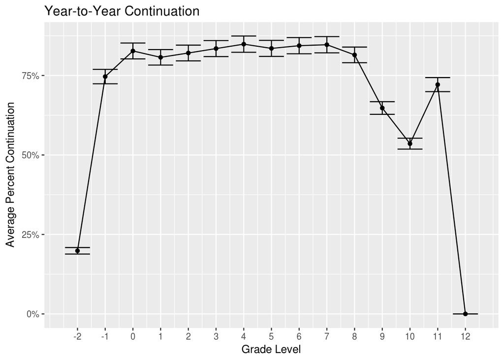

```r
continuation_rates <- df %>%
    group_by(year, grade_level) %>%
    #distinct(year, student_id_scram, did_continue) %>%
    #group_by(student_id_scram, grade_level) %>%
    summarise(continuing_students=sum(did_continue), total_students=n(), continuation_rate=continuing_students/total_students)

continuation_rates %>%
  group_by(grade_level) %>%
  summarise(avg_continuation=mean(continuation_rate), se=sd(continuation_rate)/n()) %>%
  ggplot(aes(x=grade_level, y=avg_continuation)) +
  scale_x_continuous(breaks = seq(-2, 12, 1)) +
  scale_y_continuous(labels = percent) +
  geom_point() +
  geom_line() +
  labs(x="Grade Level", y="Average Percent Continuation", title="Year-to-Year Continuation") +
  geom_errorbar(aes(ymin = avg_continuation-se, ymax = avg_continuation+se))
```

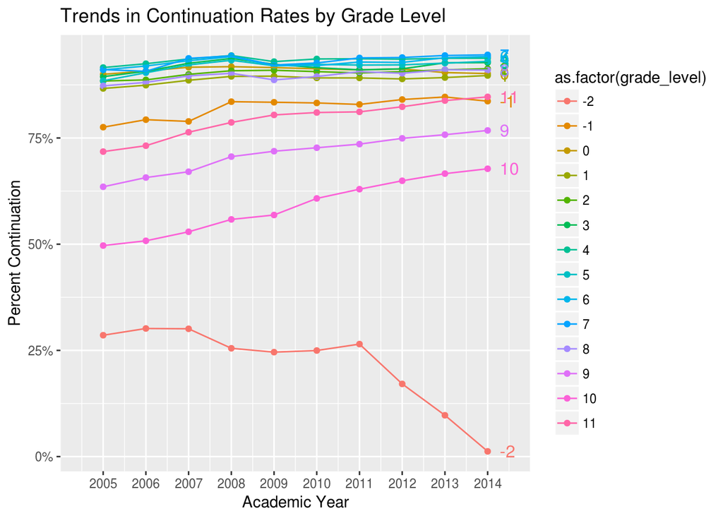

```r
continuation_rates %>%
  filter(grade_level!=12, year!=2015) %>%
  ggplot(aes(x=year, y=continuation_rate, color=as.factor(grade_level))) +
  geom_point() +
  geom_line() +
  labs(x="Academic Year", y="Percent Continuation", title="Trends in Continuation Rates by Grade Level") +
  scale_y_continuous(labels = percent) +
  scale_x_continuous(breaks=seq(2005, 2014, 1), expand=c(0, 1)) +
  geom_dl(aes(label = as.factor(grade_level)), method = list(dl.trans(x = x + .3), "last.points", cex = 1))
```

```r
new_df <-
  entries_per_student %>%
  #group_by(student_id_scram) %>%
  filter(any(grade_level==9)) %>%
  group_by(year) %>%
  #distinct(student_id_scram) %>%
  summarise(num_ninth=sum(grade_level==9),
            continued_to_tenth=sum(grade_level==9 & did_continue==1, na.rm=T),
            continued_to_eleventh=sum(grade_level==10 & did_continue==1, na.rm=T),
            continued_to_twelfth=sum(grade_level==11 & did_continue==1, na.rm=T),
            perc_ninth=num_ninth/num_ninth,
            perc_tenth=continued_to_tenth/num_ninth,
            perc_eleventh=continued_to_eleventh/num_ninth,
            perc_twelfth=continued_to_twelfth/num_ninth)

new_df
```

```
## # A tibble: 11 x 9
##     year num_ninth continued_to_tenth continued_to_eleventh
##    <dbl>     <int>              <int>                 <int>
##  1  2005    113714              72224                   144
##  2  2006    108146              71037                 48010
##  3  2007    104575              70122                 52497
##  4  2008    101327              71549                 54064
##  5  2009    100352              72138                 55070
##  6  2010     97597              70956                 57766
##  7  2011     94936              69831                 57764
##  8  2012     94350              70687                 57930
##  9  2013         0                  0                 58904
## 10  2014         0                  0                     0
## 11  2015         0                  0                     0
## # ... with 5 more variables: continued_to_twelfth <int>, perc_ninth <dbl>,
## #   perc_tenth <dbl>, perc_eleventh <dbl>, perc_twelfth <dbl>
```

```r
new_df_2 <-
  new_df %>%
  select(year, 6:9) %>%
  gather("grade", "num_students", 2:5) %>%
  arrange(year)

new_df_2$grade[new_df_2$grade=="perc_ninth"] <- 9
new_df_2$grade[new_df_2$grade=="perc_tenth"] <- 10
new_df_2$grade[new_df_2$grade=="perc_eleventh"] <- 11
new_df_2$grade[new_df_2$grade=="perc_twelfth"] <- 12

new_df_2 <-
  new_df_2 %>%
  mutate(grade=as.numeric(grade))

new_df_2
```

```
## # A tibble: 44 x 3
##     year grade num_students
##    <dbl> <dbl>        <dbl>
##  1  2005     9 1.0000000000
##  2  2005    10 0.6351372742
##  3  2005    11 0.0012663348
##  4  2005    12 0.0002462318
##  5  2006     9 1.0000000000
##  6  2006    10 0.6568620199
##  7  2006    11 0.4439369001
##  8  2006    12 0.0130009432
##  9  2007     9 1.0000000000
## 10  2007    10 0.6705426727
## # ... with 34 more rows
```

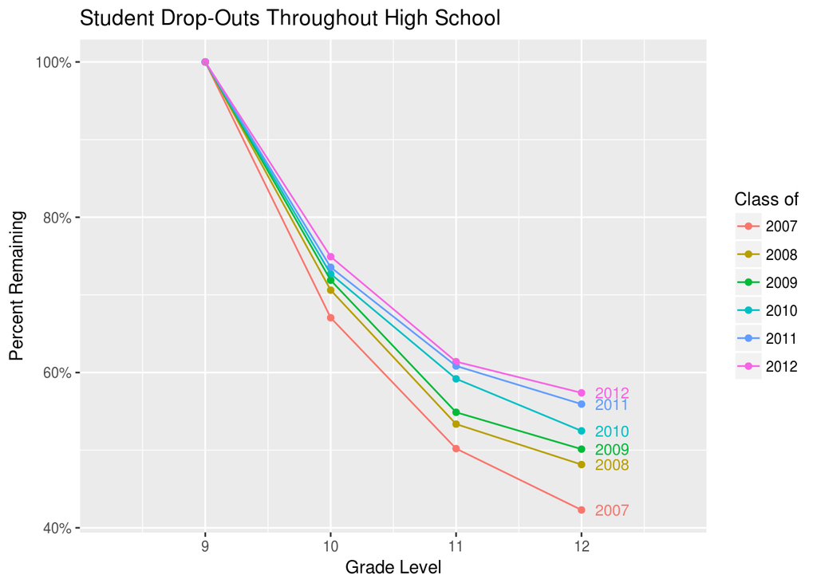

```r
new_df_2 %>%
  filter(year<=2012, year>2006) %>%
  ggplot(aes(x=grade, y=num_students, color=as.factor(year))) +
  geom_point() +
  geom_line() +
  scale_y_continuous(labels = percent) +
  scale_x_continuous(breaks=seq(9, 12, 1), expand=c(0, 1)) +
  geom_dl(aes(label = as.factor(year)), method = list(dl.trans(x = x + .3), "last.points", cex = 0.8)) +
  labs(x="Grade Level", y="Percent Remaining", title="Student Drop-Outs Throughout High School", color="Class of")
```

The general trends are consistent with the data found on nyc.gov, but our values are about 10% lower. Maybe because this graph is showing us what percent of the students made it to 12th grade, but it’s not showing us how many of those 12th graders graduate. How can we add in, for each student, whether they graduated?

We had to drop 2005 and 2006 because for some reason, it was telling us that in 2005 almost everyone dropped out after 10th grade and in 2006 almost everyone dropped out after 11th grade.